# Computer Science 1

**Computer lab 07**

**Course Number:** BTPS1210BA-E  
**Contact Information:** Please contact me through email anytime: abari.kalman@arts.unideb.hu

Author

Kálmán Abari

Published

August 31, 2024

Learning outcomes

Students will learn how to transform data.

# Jamovi - Data transformation

## Problem 1

> In this section, you will learn how to perform unit conversions.

In `dataset_xlsx.omv` (see [Lab05 Problems](https://abarik.github.io/computer_science_1_2023_24_1/labs/CS_1_lab_05_jamovi_2.html)) variable `Height` and `Weight` are measured in inches and pounds. Convert them centimeters and kilograms.

**Important systems of measurement**

The International System of Units (SI), often referred to as the metric system, is the most widely used system of measurement in the world today. It provides a standardized way of quantifying physical quantities such as length, mass, time, and temperature, making it easier for scientists, engineers, and people across different countries to communicate and work with consistent measurements. The SI system is based on a set of fundamental units and prefixes that allow for easy scaling of units across orders of magnitude.

Some important features of the SI system include seven base units, from which all other units are derived:

- **Meter (m):** The unit of length.
- **Kilogram (kg):** The unit of mass.
- **Second (s):** The unit of time.
- **Ampere (A):** The unit of electric current.
- **Kelvin (K):** The unit of temperature.
- **Mole (mol):** The unit of amount of substance.
- **Candela (cd):** The unit of luminous intensity.

The SI system also incorporates a range of prefixes, such as kilo-, centi-, and milli-, to modify these base units and make them suitable for various applications.

Apart from the SI system, there are other important systems of measurement used in specific contexts:

- **Imperial System:** Commonly used in the United States, this system employs units like inches, feet, pounds, and gallons for length, weight, and volume measurements.
- **U.S. Customary System:** Similar to the Imperial system, it’s used in the United States, but there are slight differences in some units.
- **British Imperial System:** Used in the UK and some other Commonwealth countries, it has units like the inch, foot, pound, and gallon.

Each system has its own historical and cultural significance and is applied in specific fields or regions, but **the SI system has gained global acceptance as the standard system of measurement, facilitating international scientific and technological collaboration.**

1. Open `dataset_xlsx.omv` (see [Lab05 Problems](https://abarik.github.io/computer_science_1_2023_24_1/labs/CS_1_lab_05_jamovi_2.html)) in jamovi.
2. How to convert inches to centimeters? Variable `Height` measured in inches. We activate the variable to be converted, which is now `Height`.

[figure not shown]

Variable to be converted

3. Select `Data / Compute` menu.

[figure not shown]

Insert a new variable

4. Rename the variable to `Height_cm`, and add description `Heights in centemiters`

[figure not shown]

Add name and description

5. Since 1 inch is equal to 2.54 centimeters ($1″ = 2.54cm$), type the following in the expression field: `ROUND(Height*2.54)`

[figure not shown]

Calculation

6. How to convert pounds to kilograms? Variable `Weight` measured in pounds. We activate the variable to be converted, which is now `Weight`.

[figure not shown]

Variable to be converted

7. Select `Data / Compute` menu.

[figure not shown]

Insert a new variable

8. Rename the variable to `Weight_kg`, and add description `Weights in kilograms`

[figure not shown]

Add name and description

[figure not shown]

Calculation

10. Send the file `dataset_xlsx.omv` to the `abari.kurzus@gmail.com`. The subject of this email is `Lab07 - Problem 1`.

## Problem 2

> In this section, you will learn how to insert computed variable.

A new variable may be based on more than one variable. In this problem, we wish to compute BMI for the respondents in our sample. The height (in centimeters) and weight (in kilograms) of the respondents were observed; so to compute BMI, we want to plug those values into the formula

$$BMI=\frac{\text{Weight in kg}}{(\text{Height in m})^2}$$

1. Use `dataset_xlsx.omv` from Problem 1.
2. Append a new computed variable to the dataset. Select `Data / Add / Computed variable / Append` menu.

[figure not shown]

Append computed variable

[figure not shown]

Appended variable

3. Rename the variable to `BMI`, and add description `Body Mass Index`.

[figure not shown]

Add name and description

4. Type the following in the expression field: `ROUND(Weight_kg/(Height_cm/100)^2, 2)`

[figure not shown]

Calculation

5. Send the file `dataset_xlsx.omv` to the `abari.kurzus@gmail.com`. The subject of this email is `Lab07 - Problem 2`.

## Problem 3

> In this section, you will learn how to calculate the Z-score of a variable.

In `dataset_xlsx.omv` (see [Lab05 Problems](https://abarik.github.io/computer_science_1_2023_24_1/labs/CS_1_lab_05_jamovi_2.html)) calcuate Z-scores of variables `English`, `Reading`, `Math`, and `Writing`. Name them as `ZEnglish`, `ZReading`, `ZMath`, and `ZWriting`.

**Z-score**

Calculating the Z-score of a variable is a statistical technique used to standardize and normalize data. It’s primarily done for two main reasons:

1. Comparing Different Distributions  
   Z-scores allow you to compare data points from different datasets or variables with different units of measurement. By converting the data into a common scale, you can make meaningful comparisons. This is especially useful when working with data from various sources or when you want to assess how a data point compares to the rest of the data in a distribution.
2. Identifying Outliers  
   Z-scores help in identifying outliers within a dataset. An outlier is an observation that deviates significantly from the rest of the data. Z-scores make it easier to set a threshold (e.g., ±2 or ±3 standard deviations) to flag values as outliers. This is because, in a standardized distribution, most data points should fall within a certain range around the mean, and those outside this range can be considered outliers.

The formula to calculate the Z-score for an individual data point is:

$$Z=\frac{X-\mu}{\sigma}$$

Where:

- $Z$ is the Z-score.
- $X$ is the individual data point.
- $\mu$ is the mean (average) of the dataset.
- $\sigma$ is the standard deviation of the dataset.

Here’s how Z-scores are typically used:

- If a Z-score is close to 0, it means the data point is close to the mean.
- A positive Z-score indicates that the data point is above the mean.
- A negative Z-score indicates that the data point is below the mean.

By standardizing the data with Z-scores, you can make informed decisions about the relative position of data points and identify unusual or extreme values. This can be valuable in various fields, including finance, quality control, and scientific research, where understanding data distribution and detecting outliers are important for analysis and decision-making.

In *jamovi*, you can compute standardized scores for numeric variables automatically using `Z()` function. One important distinction is that the standardized values of the “raw” scores will be centered about their sample means and scaled (divided by) their sample standard deviations; that is:

$$z=\frac{x-\bar{x}}{s}$$

1. Open `dataset_xlsx.omv` (see [Lab05 Problems](https://abarik.github.io/computer_science_1_2023_24_1/labs/CS_1_lab_05_jamovi_2.html)) in jamovi.
2. In this section, we only present the Z-transformation of the variable `English` into a new variable `ZEnglish`. We leave the transformation of the other variables to the Reader. Activate the variable to be Z-scored, which is now `English`.

[figure not shown]

Variable to be Z-scored

3. Select `Data / Compute` menu.

[figure not shown]

Insert a new variable

4. Rename the variable to `ZEnglish`, and add description `Z-score of variable 'English'`

[figure not shown]

Add name and description

5. Type the following in the expression field: `Z(English)`

[figure not shown]

Calculation of Z-score

6. Repeat the above steps for `Reading`, `Math`, and `Writing` variables.

[figure not shown]

Calculation of Z-scores

7. Send the file `dataset_xlsx.omv` to the `abari.kurzus@gmail.com`. The subject of this email is `Lab07 - Problem 3`.

## Problem 4

> In this section, you will learn how to merging categories.

Class ranks for high schools and colleges are are nicknames for what year of study the person is completing: “freshman” (first-year), “sophomore” (second-year), “junior” (third-year), “senior” (fourth-year). Class ranks are also sometimes divided into “underclassmen” (first or second-year students) and “upperclassmen” (third or fourth-year students).

In the `dataset_xlsx.omv` (see [Lab05 Problems](https://abarik.github.io/computer_science_1_2023_24_1/labs/CS_1_lab_05_jamovi_2.html)), the variable `Rank` has the categories Freshman (1), Sophomore (2), Junior (3), and Senior (4). Let’s merge the categories and create a new indicator variable called `RankIndicator` with the levels `Underclassman` (1) and `Upperclassman` (2).

1. Open `dataset_xlsx.omv` (see [Lab05 Problems](https://abarik.github.io/computer_science_1_2023_24_1/labs/CS_1_lab_05_jamovi_2.html)) in jamovi.
2. Activate the variable to be transformed, which is now `Rank`.

[figure not shown]

Variable to be transformed

3. Select `Data / Transform` menu.

[figure not shown]

Insert a new variable

4. Rename the variable to `RankIndicator`, and add description `Merging the categories of 'Rank'. Two levels: "underclassmen" (first or second-year students) and "upperclassmen" (third or fourth-year students)`

[figure not shown]

Add name and description

5. Make sure ‘Source Variable’ is set to `Rank` and select ‘Create New Transform’ from ‘Use Transform’.

[figure not shown]

Create new transform

[figure not shown]

New transform

6. Rename the transform to `Merging Rank categories`, and add description `Two levels: "underclassmen" and "upperclassmen"`.

[figure not shown]

Add name and description

7. Clicking twice on ‘Add recode condition’ and typing the following text create this state. Select ‘Ordinal’ from the ‘Measure type’.

[figure not shown]

Clicking on ‘Add recode condition’

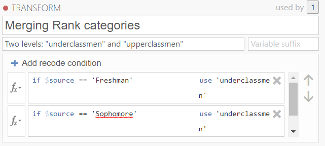

Recode condition (1-2)

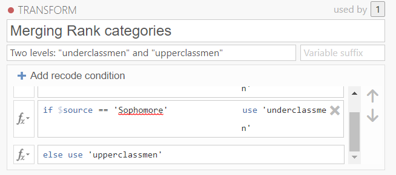

Recode condition (else)

8. Close this Transform.

[figure not shown]

Closing transform

8. Close this Transformation.

[figure not shown]

Closing transformation

7. Send the file `dataset_xlsx.omv` to the `abari.kurzus@gmail.com`. The subject of this email is `Lab07 - Problem 4`.

## Problem 5

> In this section, you will learn how to discretizing a continuous variable.

One important use of the tranformation is dichotomizing or discretizing a continuous variable. Dichotomizing a continuous variable transforms an interval/rate variable into a binary categorical variable by splitting the values into two groups based on a cut point. Discretizing a continuous variable transforms an interval/rate variable into an ordinal categorical variable by splitting the values into three or more groups based on several cut points.

In the sample dataset, the variable `CommuteTime` represents the amount of time (in minutes) it takes the respondent to commute to campus. Let’s try recoding this variable into three ordinal groups:

- 1 = Commute is 30 minutes or less (time < 30)
- 2 = Commute is more than 30 minutes, but less than 60 minutes (30 < time < 60)
- 3 = Commute is an hour or more (time > 60)

Give the new variable the name `CommuteLength`.

1. Open `dataset_xlsx.omv` (see [Lab05 Problems](https://abarik.github.io/computer_science_1_2023_24_1/labs/CS_1_lab_05_jamovi_2.html)) in jamovi.
2. Activate the variable to be transformed, which is now `CommuteTime`.

[figure not shown]

Variable to be transformed

3. Select `Data / Transform` menu.

[figure not shown]

Insert a new variable

4. Rename the variable to `CommuteLength`, and add description `Discretizing a variable 'CommuteTime'`

[figure not shown]

Add name and description

5. Make sure ‘Source Variable’ is set to `CommuteTime` and select ‘Create New Transform’ from ‘Use Transform’.

[figure not shown]

Create new transform